# 数字经济专业导论 · 两课合订（HTML 版）

四川农业大学 · 数字经济专业 **导论**

数字经济专业导论 01 / 43

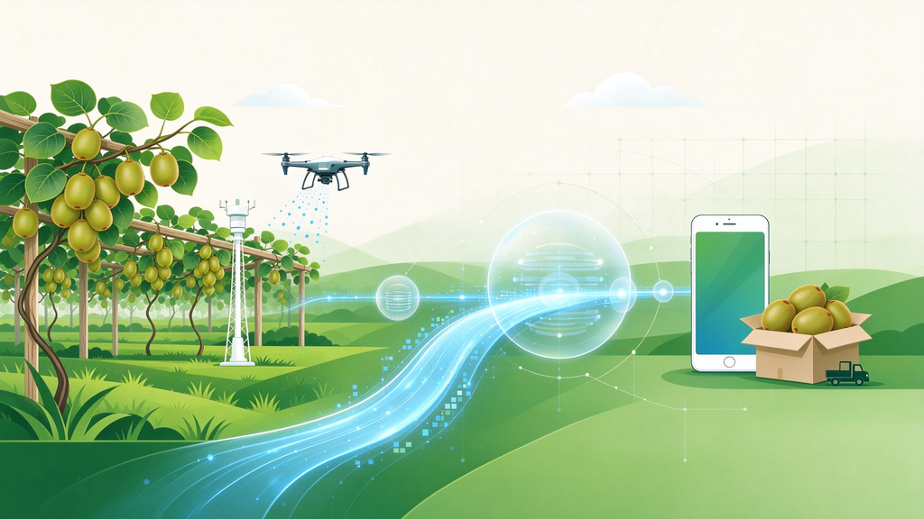

四川农业大学 · 数字经济专业

# 数字经济专业导论

2026 级新生2026年10月用真实案例认识这个专业

CONTENTS · 两课合订

## 课程大纲：八个问题，两节大课

用一个真实水果订单切入数字经济，再回答"AI 时代毕业时你凭什么被看见"

第一课 · 从一笔水果订单说起用一个真实场景，认识数字经济到底是什么

01

#### 一个问题：差价去哪了

课堂选择 · 数字经济定义 · 国家统计局口径

02

#### 数字经济的两条路

数字产业化 vs 产业数字化 · 已占 GDP 10.5%

03

#### 平台与真实农业案例

蒲江猕猴桃 · 安岳柠檬 AI 处方 · 技术如何算账

04

#### 数据要素与职业方向

第四类生产要素 · 四年后你会成为哪一类人

第二课 · AI 时代的核心能力毕业时你凭什么被看见：六项能力 · 三个门槛

05

#### 为什么要谈能力

哈佛 × BCG 实验 · 锯齿状技术前沿

06

#### 六项核心能力与工具标准

问题定义 · 数据分析 · 因果 · AI 协作 · 合规

07

#### 五个工作场景与三个门槛

平台运营 · 数字农业 · 金融 · 政策 · 数据要素

08

#### 四年培养路径与评价

证据进作品集 · 七维评价 · 毕业作品包

授课教师 · FACULTY

## 张剑 ｜副教授 · 数字经济系主任

硕士研究生导师 · 经济学院经济实验中心主任

经济学博士 · 西南财经大学（2014） 四川省数量经济学会理事

- 数字经济系主任 · 经济实验中心主任
- 用 Agent 让想法落地
- 探索新事物
- 目前研究兴趣：实验经济学与模拟仿真

电话 / 微信：18628133001 [个人主页：jefeerzhang.github.io ↗](https://jefeerzhang.github.io)

5

主持省厅级课题

6

主研国家级 · 省部级课题

20+

篇 SSCI · CSSCI 论文

27.3

累计影响因子

Top 1% ｜中国知网高被引学者 四川省教学成果二等奖 省哲学社会科学二等奖

一个词的三十年

## 数字经济：不是新词，但最近十年才成为主线

从 1996 年第一次被提出，到写进国家发展规划——它已经成为占 GDP 一成的真实经济板块

1996

概念首次提出

加拿大学者唐·塔普斯科特在《数字经济》一书中首次使用这一概念，描述互联网带来的新经济形态。

2016

G20 杭州定义

《G20 数字经济发展与合作倡议》给出国际通行定义：以数字信息为关键生产要素的经济活动。

2021

国家统计局分类

发布《数字经济及其核心产业统计分类》，给出中国官方统计口径——本门课引用的"国家定义"。

2024

占 GDP 一成

数字经济核心产业增加值 14.09 万亿元，占当年 GDP 的 10.5%（国家统计局）。

它从一个学术概念，变成了写进国家统计制度、**占 GDP 一成**的真实经济板块。

来源：Tapscott《数字经济》(1996)｜G20 杭州峰会倡议 (2016)｜国家统计局《数字经济及其核心产业统计分类》(2021)｜国家统计局 2024 年核算

国家统计局官方定义 · 2021

## 国家怎么定义，它就在做什么：四个环节

以**数据资源**为关键要素、以**现代信息网络**为主要载体、以**数字技术应用**为驱动，对**生产、交换、分配、消费**产生影响的经济形态。

### 生产

用传感器、AI 模型改造田间与车间——智能灌溉、AI 分选、精准养殖。

### 交换

用平台与算法撮合买卖双方——电商、外卖、即时配送，重新组织交易。

### 分配

数据本身成为生产要素，按贡献参与分配——数据资产入表、数据产品交易。

### 消费

用推荐与即时履约改变你的选择——开头那笔水果订单，就是消费端。

易错点：数字经济 ≠ 网上卖东西。网店、外卖只是它在"交换"和"消费"端的一角，真正的覆盖面是四个环节。

口径：国家统计局《数字经济及其核心产业统计分类（2021）》

一个公式看懂多了什么

## 柯布-道格拉斯生产函数的数字经济扩展

学界就是这样把"数据"写进增长模型的

工业经济时代

*Y* = *A* · *K*<sup>α</sup> · *L*<sup>β</sup>

Y 产出 · A 全要素生产率 · K 资本 · L 劳动 · 假设 α+β=1（规模报酬不变）

→＋数据 D

数字经济时代

*Y* = *A*(*D*) · *K*<sup>α</sup> · *L*<sup>β</sup> · *D*<sup>γ</sup>

新增 D = 数据要素（第四要素）· γ = 数据产出弹性 · A 也被数字技术抬升

① 乘子

### 新增一个乘子

D 直接进入生产函数——数据不再只是"辅助"，而是和 K、L 并列的独立要素。

② TFP

### A 被数字技术抬升

同样的 K 和 L，靠算法与 AI 调度，产出更高——这就是全要素生产率的提升。

③ 报酬

### 规模报酬可能递增

传统假设 α+β=1；数据非竞争、可复用、越用越准，总和可能 >1。

参考：中国人民大学学报《基于数据要素的数字经济增长与核算理论》(2025)；信通院《新质生产力研究报告》(2024)；Dell'Acqua et al. (2026)

课堂情境 · 先选一个

## 同一盒猕猴桃，三种买法三种价——你选哪个？

课堂情境（模拟）：同一盒猕猴桃，从蒲江果园到你手里——先在心里选一个，记下理由，答案课后半段揭晓

01

校园超市自提

9.9 元/盒

楼下就有，代价是自己跑一趟，还要赶在打烊前。

02

即时配送

12.9 元 + 3 元配送

30 分钟送到宿舍门口，时间最贵，也最省你的脚力。

03

平台下单

7.9 元/盒

明日达 · 今晚还想吃吗？

同一盒最便宜；但页面写着「明日达」——时间换价格。

**差价去哪了？**2025 年蒲江猕猴桃产地均价约 **8.9 元/公斤**（10.07 亿元产值 ÷ 11.32 万吨）——你这盒 9.9 元，差价去哪了？

课堂模拟 · 非真实报价；产地均价为教案数据演算，不等于果农到手价

基本概念 · WHAT

## 每一次点击，都在产生数据

### 数据资源

你的选择、位置、评价，都在变成可记录、可分析的数据——刚才那笔订单就是。

### 现代信息网络

手机、基站、云端，把分散在各处的数据连成一张网，让信息即时流动。

### 数字技术应用

算法把数据变成推荐、定价、调度与决策——比如平台给你的优惠券。

数字经济：以数据资源为关键要素、以现代信息网络为主要载体、以数字技术应用为驱动，对生产、交换、分配、消费产生影响的经济形态。

易错点：别把网上卖东西当成数字经济——网上交易额不等于数字经济增加值，网店与外卖只是它的一角。

教学转述 · 口径依据：国家统计局《数字经济及其核心产业统计分类（2021）》

两种数字化 · 两个方向

## 数字经济分两条路：造数字的，与用数字的

ROAD A · 供给方

### 数字产业化

提供数字产品与服务本身

云服务、芯片、软件、互联网平台——它们是数字经济的「供给方」，把数字能力本身做成产业。

云服务芯片制造

ROAD B · 应用方

### 产业数字化

用数字能力改造原有产业

农业、制造、物流、金融——用数据与数字技术提升原有产业的效率、质量与收益。

果园智能灌溉商家线上订单分析

课堂提问：云服务、芯片制造、果园智能灌溉、商家线上订单分析，分别放进哪一栏？

分类口径参考：国家统计局《数字经济及其核心产业统计分类（2021）》

国家统计局 · 2024 年核算

## 数字经济核心产业，已占全国 GDP 的一成

2024 年数字经济核心产业增加值 = 140,891 亿元

平均每 100 元 GDP 中，约 **10.5 元**来自数字经济核心产业——它已是国民经济的重要支柱。  
口径：数字经济核心产业，不含全部数字经济相关活动

来源：国家统计局 2024 年国民经济核算（2025-12 发布）｜国家统计局统计分类解读

平台经济学 · 回到水果订单

## 平台不是中间商，是市场的撮合者

平台同时服务消费者、商家与配送者——它本身就是数字经济的主角：① 数字产业 ② 产业数字化入口 ③ 数据要素集散地

平台

消费者

商家

配送者

01

### 搜寻与匹配成本

评价、搜索、算法，让买卖双方更快找到彼此。

02

### 网络效应

用的人越多，平台对每个人越有价值。

03

### 激励与利益分配

佣金、补贴、运费怎么分，决定平台生态。撮合产生数据，数据再反哺撮合。

课堂讲解 · 平台经济学基础概念；关系图为示意结构

课堂视频 · 08

## 平台经济，不是中间商

配合第 7 页概念使用——点击卡片，在飞书中打开视频

**▶ 点击播放** 平台经济，不是中间商飞书文件 ↗

真实案例 · 四川成都蒲江

## 一颗蒲江猕猴桃的数字化之旅

从果园到餐桌，四个环节都在被数据重新组织

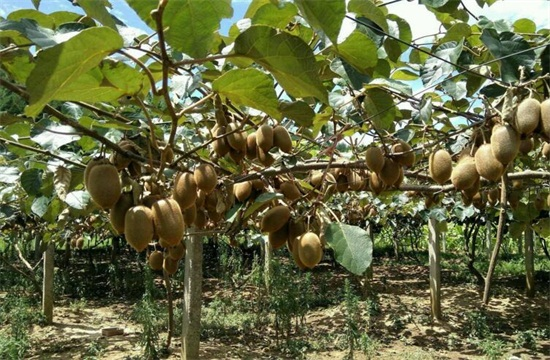

蒲江猕猴桃种植园 · 公开报道配图

01 生产监测

#### 土壤大数据 + 物联网

采集 130 万余条数据；物联网基地 20 余个、节水灌溉 5 万亩，亩均人力成本降 30% 以上。

02 智能分选

#### 单果每秒 56 张照片 · 12 项检测

瑕疵识别准确度 90%，二维码成为猕猴桃「身份证」。

03 冷链保鲜

#### 114 间气调保鲜库 · 静态库容超 20 万吨

智慧气调加即食催熟，把销售周期从 3 个月延长到 8 个月。

04 线上销售

#### 电商主体 8050 余家 · 年发货超 1 亿件

品牌价值 131.02 亿元。

**6 万亩**2025 年种植面积

**11.32 万吨**年产量

**10.07 亿元**年产值

来源：蒲江县农业农村局答复函（2026）｜四川省农业农村厅（2022）｜红星新闻（2024）｜人民网四川（2026）

成本 · 时间 · 价格

## 数字化不是口号，是一笔算得清的账

数字化的价值，最终要落到成本、时间与价格上（真实数据，标注年份）

| 数字化环节 | 技术动作 | 经济结果（数据年份） |
| --- | --- | --- |
| 物联网监测 | 土壤与气象传感器 ＋ 大数据平台 | 亩均人力成本 -30% 以上（2022 省厅） |
| 智能分选 | 单果每秒 56 张照片 ＋ 12 项品质检测 | 瑕疵识别准确度 90%（2024 红星新闻） |
| 气调冷库 | 智慧气调 ＋ 精准温控 ＋ 即食催熟 | 销售周期 3→8 个月，6 万吨错峰上市（2026 人民网） |
| 电商平台 | 线上订单 ＋ 产地直发 ＋ 冷链物流 | 年发货超 1 亿件，产地均价预计 +30%（2026 蒲江答复函） |

算得清这笔账，就是数字经济专业的基本功——**成本、时间、价格，处处可计量**。

来源：四川省农业农村厅（2022）｜红星新闻（2024）｜人民网四川（2026）｜蒲江县农业农村局答复函（2026）

真实案例 · 四川资阳安岳

## AI 给柠檬树开「电子处方」

数字化发生在生产端，AI 直接参与农事决策 种植面积 48 万亩 产量占全国约 70%

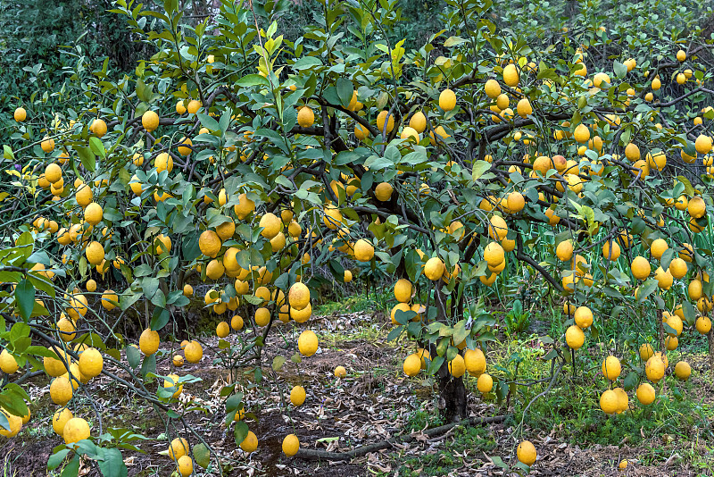

安岳柠檬园 · 公开报道配图

第一步

「天-空-地-人」四维监测网采集果园数据

第二步

柠檬作物模型平台生成个性化农事处方

第三步

AI「电子处方」推送到农户手机，像医生开方一样

**-30%**人力成本

**-25%**农资投入

**+35%**单产

**85%+**商品果率

示范园一年成效：曾提前预警红蜘蛛，帮农户避免数十万元损失。2026 年 1 月入选《2025 年全国智慧农业典型案例汇编》，是资阳市首个国家级智慧农业样板。

「数据像医生一样看诊，AI 像处方一样开方」 来源：农业农村部农产品质量安全中心（2026-01）｜四川在线（2026-01）｜安岳县政府（2025）

第四类生产要素

## 数据要素：与土地、劳动、资本并列

土地劳动资本＋ 数据 D

什么是数据要素？

能以数据形态参与生产、被记录、复用与交易的生产要素——数字经济定义里的「关键要素」，说的就是它。

01

#### 可复制，不消耗

同一份数据可被反复使用，不像土地、设备那样越用越少。

02

#### 可共享，不排他

数据能同时供多方使用，用得越多、价值越大。

03

#### 越用越准

在使用中不断积累与校正，数据价值随规模上升。

**从记录到资产：**蒲江 130 万余条土壤数据 → 精准灌溉（记录→决策）；南充柑橘数据产品挂牌深数所、获银行授信 1.1 亿元（数据→资产，第二节展开）。

易错提醒：统计分类里的「数字要素驱动业」（占 18.8%）是**产业类别**；这里讲的是「数据要素」**本身**——两者相关，但不是一回事。

课堂视频 · 13

## 数据要素，一分钟看懂

**▶ 点击播放** 数据要素，一分钟看懂飞书文件 ↗

四年后的你

## 四年后，你会成为哪一类人？

#### 数据运营分析

蒲江电商团队：看数据决定上架什么、卖给谁、怎么定价。

#### 供应链管理

冷链与物流：让水果在 48 小时内从田间到餐桌（即食猕猴桃实践）。

#### 数字金融

数据产品获银行授信 1.1 亿元（南充案例）——谁来评估它的价值与风险？

#### 政策评估研究

国家级智慧农业样板如何推广、效果如何评估——谁来研究并制定规则？

**课堂讨论｜**电商平台抽成——是"帮农民卖货"，还是"薅农民羊毛"？ 讨论 1 分钟：正反各说一个理由，再回到岗位话题。

南充数据产品授信：南充市政府（2026）

课堂讨论 · 你来当一次合作社负责人

## 账上 50 万，四件事里选两件先上——你选哪两个？

¥ 500,000

假如你是蒲江猕猴桃合作社的负责人，账上 50 万启动资金。四件事里选两件先上——你选哪两个？为什么？

① 物联网监测

#### 传感器 ＋ 大数据平台

亩均人力成本 -30%

② 智能分选

#### 单果 56 张照片 ＋ 12 项检测

瑕疵识别 90%

③ 气调冷库

#### 精准温控 ＋ 催熟

销售周期 3→8 个月

④ 电商平台

#### 产地直发 ＋ 冷链

年发 1 亿件，均价 +30%

讨论提示：哪一项**回本最快**？哪一项决定你能不能**卖到好价钱**？如果四项都上，先后顺序是什么？——这就是数字经济专业要回答的"优先级"问题。

3 分钟同桌讨论 · 每组派代表说一句你的选择和理由

第一课 · 回顾

## 数字经济专业：让传统产业变聪明的学问

回到开头的提问：你的水果订单选择，今天解释清楚了吗？

01

### 数字经济 = 数据 + 网络 + 数字技术，改变生产与交易

02

### 平台解决三件事：找人、聚人、分钱

03

### 数字农业就在我们身边：蒲江的猕猴桃、安岳的柠檬

数字经济专业导论 · 第二课

## 毕业时， 你凭什么被看见？

数字经济专业毕业生的核心能力：AI 时代（修订稿）  
六项核心能力 · 三个毕业门槛 · 组织协作与持续学习贯穿全程

2026 级新生 · 第二课

反直觉的实验证据

## 用 AI 用得越多，就一定越对吗？

哈佛商学院 × BCG 预注册实地实验（758 名顾问，Organization Science, 2026）——它决定了本课的能力排序

任务在 AI 能力范围内

+25% 速度

+40% 质量

使用 GPT-4 的顾问：速度提高 25% 以上，质量提高 40% 以上。

VS

任务刻意放在 AI 能力边界之外

-19 个百分点

用 AI 的顾问得出正确结论的概率，比不用 AI 的低 19 个百分点。

**「锯齿状技术前沿」：**AI 的能力边界参差不齐，事先看不出来。不会核验的人用了 AI，可能**错得更自信**。

来源：Dell'Acqua 等《Navigating the Jagged Technological Frontier》，Organization Science, 2026

核心能力和目标

## 四年后：独立走完从问题到落地的完整流程

#### 发现问题

现场观察

#### 可靠分析

数据 + AI + 验证

#### 交付建议

能用、能维护

#### 检查效果

使用后评价

能在现场发现一个经济问题，用数据与 AI 做出可靠分析，把建议交付给使用者，并持续检查效果。

#### 核心判断 · 若只优先三项

经济判断力、数据分析与验证、AI 协作解决问题。

#### 落地支撑

行业与数据要素理解、沟通与合规，决定能力能否进入真实场景。

依据：本专业人才培养方案与《数字经济专业毕业生的核心能力：AI 时代（修订稿）》

框架总览

## 能力全景：六项核心 ＋ 三个门槛 ＋ 两贯穿

整课只讲这一套框架：六项能力打底，三个门槛检验组合使用，两贯穿全程

| 毕业门槛 | 主要调用的能力 | 毕业作品中的对应证据 |
| --- | --- | --- |
| 门槛一 · 现场发现问题 | 能力 1 经济问题定义、能力 5 行业与数据要素、能力 6 沟通 | 观察与访谈记录、决策问题说明 |
| 门槛二 · 可维护地交付 | 能力 2 数据整理、能力 4 AI 协作与流程设计 | 数据字典、可运行流程、交接演示 |
| 门槛三 · 使用后评价 | 能力 3 因果与模型评价、能力 4 AI 协作、能力 6 合规 | 试用记录、AI 测试集与错误分析、监测计划 |

**贯穿要求：**组织协作与改变工作方式 ＋ 自主更新与跨领域学习，贯穿三个门槛。

框架：数字经济专业毕业生的核心能力：AI 时代（修订稿）· 能力框架总览

一、六项核心能力

## 六项核心能力，每项都有可观察的表现

能力 1–3 是判断与验证，能力 4 是人机协作，能力 5–6 决定落地

1

#### 经济问题定义与判断

把"提高销量"改写为明确的决策问题；识别激励、交易成本、市场关系与利益分配。

2

#### 数据整理与量化分析

解释数据来源、口径和样本；整理数据、计算指标、制作图表，说明结论适用范围。

3

#### 因果识别与模型评价

分清描述、预测与因果；检查比较是否公平，评价模型错误类型、群体表现与实际代价。

4

#### AI 协作与流程设计

拆解任务、给 AI 业务定义与数据背景、检查生成内容、留下可复现步骤、处理异常。

5

#### 行业理解、数据要素与投入产出

理解农业、平台、供应链、金融场景的流程与成本；说明数据从哪里来、归谁持有、怎样流通定价。

6

#### 沟通、协作与数据合规

面向不同对象解释结论；识别个人信息与重要数据、判断授权要求；标注 AI 生成内容。

来源：修订稿 · 一、六项核心能力（课程归属见培养方案）

六项核心能力 · 21

## 能力 1 · 经济问题定义与判断

排第一位：问题定义错了，后面的分析再漂亮也是白做

01

ABILITY

### 经济问题 定义与判断

#### 能做什么

把"提高销量"一类宽泛目标，改写成明确的决策问题；识别激励、交易成本、市场关系与利益分配。

#### 支撑课程

微观经济学数字经济学博弈论和信息经济学网络与平台经济学

#### 回扣第一课

"差价去哪了"就是一个经济问题——供需、中间环节、成本结构各承担多少？**会定义问题，才谈得上分析。**

来源：修订稿 · 一、六项核心能力 · 能力 1

六项核心能力 · 22

## 能力 2 · 数据整理与量化分析

把数据变成可核对的事实：来源、口径、样本，一个都不能糊

02

ABILITY

### 数据整理 与量化分析

#### 能做什么

解释数据来源、口径和样本；整理数据，计算合适的指标，制作图表，并说明结论的适用范围。

#### 支撑课程

Python 语言基础统计学 B数据库原理与应用经济统计分析与软件应用实验

#### 回扣第一课

蒲江猕猴桃"亩均人力成本下降 30%"——先问口径：**哪年的数据？哪个样本？怎么算的？**口径说不清的数字，不可用于决策。

来源：修订稿 · 一、六项核心能力 · 能力 2

六项核心能力 · 23

## 能力 3 · 因果识别与模型评价

相关 ≠ 因果；准确率高 ≠ 模型可用——这两句话是本专业的看家本领

03

ABILITY

### 因果识别 与模型评价

#### 能做什么

分清描述、预测与因果；检查比较是否公平，评价模型的错误类型、在不同群体中的表现以及实际代价。

#### 支撑课程

计量经济学 B机器学习与数据挖掘经济预测与决策

#### 反直觉例子

95% 的客户不违约，模型把所有客户都判为"不违约"，准确率 95% 却一个违约客户都没识别出来——该看**召回率、精确率、AUC 和代价**。

来源：修订稿 · 一、能力 3；案例三（数字金融，教学模拟）

六项核心能力 · 24

## 能力 4 · AI 协作与流程设计

AI 不是自动答题机，而是需要你设计、检查、兜底的工作伙伴

04

ABILITY

### AI 协作 与流程设计

#### 五步工作法

拆解任务→给 AI 业务定义与数据背景→检查生成内容→留下可复现步骤→处理异常

#### 最直接的技术落点

用 Python 调用大模型 API 批量处理文本或表格（分类、信息抽取），用人工标注的小样本评估输出准确率。

#### 为什么排在验证之后

"锯齿状技术前沿"：边界内提速提质，边界外反而更差；不会核验的人，错得更自信。

来源：修订稿 · 一、能力 4 与工具标准 · 大模型 API

六项核心能力 · 25

## 能力 5 · 行业理解、数据要素与投入产出分析

数字经济和数据科学、统计学的区别：把数据当作生产要素来分析

05

ABILITY

### 行业理解 数据要素 投入产出

#### 能做什么

理解农业、平台、供应链、金融场景的流程与成本；比较技术方案的收益、实施条件与风险；估算数据产品的成本与收益。

#### 四个必答问题

数据谁产生、谁持有、谁有权授权？三种流通方式风险收益差在哪？数据产品怎么定价？什么条件能确认为资产？

#### 制度框架已初步成形

2022 年 12 月"数据二十条"提出持有权、加工使用权、产品经营权**"三权分置"**；财政部规定自 2024 年 1 月 1 日起企业可将符合条件的数据资源确认为无形资产或存货（**"数据资产入表"**）。

来源：修订稿 · 一、能力 5 补充（数据二十条；财政部《企业数据资源相关会计处理暂行规定》）

六项核心能力 · 26

## 能力 6 · 沟通、协作与数据合规

"数据责任"要落到具体规则上——至少了解这四条底线

| 规则（施行时间） | 毕业生的核心义务 |
| --- | --- |
| 《个人信息保护法》 2021-11-01 | 处理个人信息须告知并取得同意；提供他人信息须单独同意；自动化决策不得在交易价格等条件上实行不合理差别待遇（第二十四条）。 |
| 《数据安全法》 2021-09-01 | 数据分类分级保护与重要数据管理。 |
| 《生成式人工智能服务管理暂行办法》 2023-08-15 | 生成式 AI 服务提供者的训练数据与内容管理义务。 |
| 《人工智能生成合成内容标识办法》 2025-09-01 | AI 生成的文本、图片、音视频须添加显式或隐式标识，不得恶意删除或篡改。 |

**落到日常：**标注 AI 生成内容、判断告知同意与授权要求、指出分析局限——贯穿所有项目。

来源：修订稿 · 一、能力 6 补充 · 合规底线

工具能力的建议标准

## 工具不是越多越好，标准要配能力

以 Python 为主线随课程逐步扩展；用基础数学、统计和代码阅读能力核验 AI 输出

| 工具 | 建议能力标准 |
| --- | --- |
| Python | 读取、清理、分析小型数据；阅读、修改、调试 AI 生成的代码，并解释输出。 |
| SQL | 常见查询、分组统计和多表关联（能力建议，培养方案未单列课程）。 |
| 表格与可视化 | 检查公式与指标口径，熟练使用至少一种可视化工具（Python、R、Tableau 等）。 |
| 统计与计量 | 选对基础方法、检查假设、评价样本外表现，区分相关、预测与因果。 |
| 大模型 API | 用 Python 调用大模型 API 批量处理文本或表格，用人工标注小样本评估准确率。 |
| 版本管理 Git | 管理代码与数据处理脚本，写清每次更新的内容和原因——门槛二的前提。 |
| AI 工具 | 搭建带来源、可检查、可重复的工作流程，并评价它是否真正改善了工作。 |

来源：修订稿 · 一、工具能力的建议标准（与旧版相比新增大模型 API 与 Git）

二、五个工作场景

## 五个工作场景，训练能力的组合拳

均为教学模拟场景，训练判断过程，不追求唯一答案

案例一 · 平台运营

#### 优惠券真的增加了购买吗？

*1**2**3*

案例二 · 数字农业

#### 先买 AI 分选设备，还是加直播投入？

*5**2**6*

案例三 · 数字金融

#### 准确率 95% 的风控模型能用吗？

*3**6**2*

案例四 · 政策研究

#### 数字化服务帮农户增收了吗？

*3**1**6*

案例五 · 数据要素

#### 合作社收购数据能否用于社员授信？

*5**6**1*

**共同点：**每个场景都在练"追问"——AI 给的结论先别信，先问：这因果吗？口径对吗？谁能用？

来源：修订稿 · 二、五个工作场景（未标注来源的数据与情境均为教学模拟）

附录 · 入学第一课

## 学校规则，务必熟悉

评奖评优、保研加分、资助申请，都以学校文件为准——这些规则越早弄清楚，越少走弯路

学生处 · 文件汇编 → 制度文件（常备）

**2025 年学生手册**一切规则的母本，先通读一遍

**学生工作管理办法**校学发〔2025〕12 号

**本专科生国家奖助学金评审办法**学发〔2025〕5 号

**家庭经济困难学生认定工作实施细则**学发〔2025〕6 号

**国家助学金评定工作实施细则**学发〔2025〕7 号

**学生勤工助学管理办法**学发〔2026〕2 号

**服兵役高等学校学生国家教育资助实施细则**学发〔2025〕8 号

[完整目录：四川农业大学学生工作部（处）官网 → 文件汇编 → 制度文件 ↗](https://xsc.sicau.edu.cn/wjhb/zdwj.htm)

竞赛获奖认定 · 只认名单内项目

**218**项认定竞赛  
2025–2026 年度名单

**106**国家级（含行业协会、学会主办）

**109**教育厅级

**3**部省级

综合测评、评奖评优、保研加分时，**只有这份名单里的竞赛获奖才被学校认定**。报名前先查名单——别辛苦一年，奖项却不计入。

📎 点击下载附件：指导学生竞赛奖认定项目名单2025–2026 年度 · PDF · 139 KB · 共 7 页

来源：四川农业大学学生工作部（处）· 文件汇编《制度文件》（xsc.sicau.edu.cn/wjhb/zdwj.htm）｜附件《2025-2026 年度指导学生竞赛奖认定项目名单》

案例一 · 平台运营（教学模拟）

## 优惠券，真的增加了购买吗？——训练能力 1、2、3

**AI 的结论：**"领券用户购买更多，因此应增加优惠券预算。" 毕业生要怎么追问？

①

领券用户是否**原本就更愿意购买**？本来会原价买的人领了券，只是让利（蚕食效应），没有带来额外订单。

②

长期看，用户会不会养成"等券再买"的习惯，价格敏感度是否上升？

③

分析应比较**增量订单、补贴成本、毛利和复购**；条件允许做随机分组试验，做不了则用上线时间差异做**双重差分**，并写明假设。

④

建议要说明适用人群、对照方式与**停止条件**。

来源：修订稿 · 二、案例一（教学模拟）；训练能力 1、2、3

案例五 · 数据要素（教学模拟）

## 合作社收购数据，能否用于社员授信？

一家合作社积累了三年的收购、分级与结算数据，本地银行希望用它给社员发放信用贷款——学生要回答五个问题

| 五问 | 要判断什么 |
| --- | --- |
| 授权主体 | 数据由谁持有、谁有权授权，合作社与社员个人各自的权利边界。 |
| 个人信息 | 涉及的个人信息如何告知社员、如何取得**单独同意**（个保法）。 |
| 提供方式 | 直接交付原始数据 ／ 只提供脱敏统计指标 ／ 隐私计算**"可用不可见"**评分服务——三种方式的风险与收益。 |
| 对价与定价 | 合作社能获得什么对价，按什么依据定价。 |
| 会计处理 | 这批数据在合作社账面上能否确认为数据资源，需要满足什么条件（数据资产入表）。 |

交付物：**一份合作社理事会能看懂的方案比较。**

三、三个毕业门槛

## 三个毕业门槛：从分析延伸到交付

一个完整数字化项目：发现需求 → 做出能用的方案 → 投入使用 → 持续衡量效果与风险

门槛 01

### 现场发现问题

会分析现成数据还不够，要发现数据里没有记录的问题。

门槛 02

### 可维护地交付

把常用分析整理成别人也能用、出错能修的流程。

门槛 03

### 使用后评价

知道 AI 在哪些任务可靠、哪些错误代价高、上线后怎么发现变化。

**共同逻辑：**门槛检验的不是会背知识，而是能在真实场景中组合使用六项能力并**留下证据**。门槛三尤其不能省略——"锯齿状技术前沿"说明不会核验的人用了 AI 可能错得更自信。

门槛三 · 使用后评价

## AI 系统的评价与治理

会调用 AI 之后，还要知道它在哪些任务上可靠、哪些错误代价高、上线后怎样发现变化

### 学生应能

准备有代表性的测试样本；比较人工流程与 AI 辅助流程的**质量、耗时与成本**；规定人工复核和异常升级的条件；收集真实使用者的反馈。

### 可检查的成果

测试集与评分口径、人工基线、错误分析、转人工规则、上线后监测计划。评价对象是解决特定任务的系统——**"用了最新模型"不计入成绩**。

**依据：**NIST AI 风险管理框架（AI RMF 1.0, 2023）把可信性纳入 AI 的设计、使用、评价与风险管理；2024 年 7 月生成式 AI 专篇（NIST AI 600-1）针对人机配置等 12 类生成式 AI 风险给出建议动作。  
**例子：**合作社用 AI 回答柑橘病虫害咨询，先建测试集，上线后记录答错类型、高危问题转农技人员。

来源：修订稿 · 三、门槛三；NIST AI RMF 1.0（2023）与 NIST AI 600-1（2024）

两个贯穿要求

## 两贯穿：组织协作 ＋ 自主更新

技术方案要真正起作用，靠的不只是代码，还有人和变化

贯穿一 · THROUGHOUT 01

### 组织协作与改变工作方式

识别决策者、使用者和受影响者；设计小范围试用、培训、反馈与调整机制。

依据：OECD（Green, 2024）——多数受 AI 影响的劳动者不需要专门的 AI 开发技能；AI 高暴露职业中需求增长最多的是**管理与商业技能**。

贯穿二 · THROUGHOUT 02

### 自主更新与跨领域学习

读懂一手资料、快速学习陌生工具或行业、做小型验证，并向团队讲清适用条件。

依据：WEF《未来就业报告 2025》——分析性思维是最受重视的核心技能，预计到 2030 年劳动者平均 **39% 的核心技能**将发生转变或过时。

**两者的关系：**协作让方案有人用，学习让能力跟得上——它们贯穿三个门槛，毕业后依旧管用。

来源：修订稿 · 三、贯穿要求一、二（OECD 2024；WEF 2025）

四、四年培养路径

## 四年培养路径：证据进作品集

课程归属以培养方案实际开课学期为准；每个阶段的证据都进入作品集

大一

#### 经济直觉；Python 与表格基础；AI 使用习惯

建立经济学的直觉与问题意识，养成"凡事先问口径"的习惯。

**阶段性证据：**一份标明来源和口径的小型数据整理与图表，附 AI 使用记录。

大二

#### 统计方法；数据库与 SQL；把宽泛问题改写为决策问题

掌握描述性分析与数据存取，学会提出可回答的问题。

**阶段性证据：**一份可复现的描述性分析，附 SQL 查询、数据字典和 Git 提交记录。

大三

#### 因果识别与模型评价；行业与数据要素；现场调查

进入真实场景，做带对照的分析，评价模型而不只是调用。

**阶段性证据：**一次带对照的因果分析或一份模型评价报告；一份现场观察与访谈记录。

大四

#### 三个门槛的整合交付

从现场问题到使用后评价，独立交付一个完整项目。

**阶段性证据：**完整的毕业作品包与答辩（见下一页评价体系）。

来源：修订稿 · 四、四年培养路径（建议）

五、评价维度与建议权重

## 怎么评价：七个维度，权重说话

"经济问题定义与机制"与"方法与验证"并列最高权重——经济推理薄弱的作品拿不到高分

经济问题定义与机制20%

说清谁需要作什么决定；识别激励、成本与利益分配；核心指标与机制对应。

现场需求10%

有观察或访谈证据；区分使用者提出的要求和真实困难。

数据与可维护交付15%

标注来源与口径；提供可运行流程、异常处理和交接说明。

方法与验证20%

方法与问题匹配；检查比较条件、模型表现和不确定性。

AI 评价与合规10%

说明 AI 参与的步骤；测试样本、错误类型、人工复核与监测；符合授权与标识要求。

试用与组织落地10%

记录用户试用、相关人员反馈、实施障碍和调整依据（按分档计分）。

建议与表达15%

比较收益与成本，说明适用与停止条件，能向非技术对象讲清楚。

来源：修订稿 · 五、评价维度与建议权重（教学建议，非培养方案正式比例）

等级 · 试用分档 · 作品包 · AI 边界

## 真实记录，比结果好看更重要

试用造假按学术不端处理

#### 试用分档

A 真实用户试用 · 可得满分B 模拟用户 · 最高 70%C 专家评审替代 · 最高 60%

分档决定"试用与组织落地"维度的得分上限，鼓励走到真实使用者面前。

#### 毕业作品包 7 件

① 需求说明 ② 数据集与分析流程 ③ 试用反馈 ④ 决策建议 ⑤ AI 评价记录 ⑥ AI 使用声明 ⑦ 答辩（现场复现）

#### AI 使用边界

**《学位法》（2025-01-01）第三十七条：**代写、剽窃、伪造属学术不端，可撤销学位。  
AI 可用于**资料整理、代码辅助、初稿润色**；**问题定义、方法选择、结果解释与结论必须本人完成。**

**答辩两问：**① 改变一个条件（物流成本上升、目标群体变化），结论是否改变、为什么；② 现场复现或修改某一步分析，确认由本人完成、本人理解。

来源：修订稿 · 五、试用分档 / 作品包 / AI 使用边界（《学位法》第三十七条）

课余交流活动 · SALON

## AI 智能体使用经验沙龙

不是讲座，是经验交换

### 带问题来， 带答案走

你踩过的坑、你挖到的好用工具，都可以带来聊。你怎么用 AI 写作业、做数据分析、搞社团运营？周三中午，我们一起聊。

走廊边不用报名路过就能加入欢迎所有专业同学

每周三

12:40

**7 教 1317 门口**数字经济系 · 课余交流活动

## 回到开头的问题： 毕业时你凭什么被看见？

能发现真实问题的人

能把方法用对、能验证 AI 的人

能把建议交付给使用者的人

这三件事，就是数字经济专业四年要给你的。

**立刻可以做的一件事：**给今天听到的一个案例写一段"如果我接手，我会先追问什么"，保存到自己的作品集目录——这就是能力 1 的第一份证据。